# Diabetes in Pima Indian Females

Andy Williams

2024-09-02

## Foreword

This page contains the R Markdown version of a paper I wrote during my Master’s Program. I have not edited the content to remove any blemishes that I have found in hindsight. The formatting will be slightly different than the Word document I submitted to my professor. This is simply a duplication of my school work meant to serve as a sample project for potential employers.

# Diabetes in Pima Indian Females

### Introduction

Type 2 Diabetes is an extremely prevalent disease in the United States. In 2022, the CDC published the *National Diabetes Statistics Report* and found 11% of U.S. adults have diabetes, but that number only includes adults who are aware of their diabetes. In addition, over 100 million adults are prediabetic and at risk of developing Type 2 Diabetes without lifestyle changes (United States Center of Disease Control, 2022). While each individual’s risk of diabetes will be different, environmental factors can also influence that level of risk. The United States Department of Agriculture estimates about 10% of the census tracts in the U.S. are “food deserts” – places where the people living there are far away from affordable sources of healthy food, which makes it difficult to follow medical guidelines to reduce risk of diabetes (United States Department of Agriculture, 2022). In addition, a distinct lack of viable travel options for persons without a motor vehicle is rampant in the United States. By my own observation, very few people get exercise from walking or cycling short distances to shop or go to work, meaning most people get no daily exercise at all unless they go to their local gym.

This leads to the Gila River Indian Community, located in Arizona and home to the subjects of the Pima Indian Diabetes dataset. The USDA Food Desert map labels the reservation as having “low income” but not “low access” to healthy food. In the 1880s, development products upstream damaged the reservation’s agricultural output, leading to a government intervention in 1908, and that combination of poor farming conditions and the provided rations being less healthy is blamed for the reservation developing a high rate of Type 2 Diabetes. Researchers began a longitudinal study of individuals in the region in 1965 (Radin, 2017).

However, the dataset resulting from that study has arguably been misused in the era of Big Data. Firstly, due to their very specific history outlined above, the Gila River Reservation is very likely to be unrepresentative of a general population who abandoned community farming long ago. In addition, the data has been used to train models meant for non-medical use, due to the data’s open availability and favorable formatting for machine learning (Radin, 2017). **In order to not repeat mistakes, this paper’s hypothesis is to use the dataset to find health factors that separate diabetics from non-diabetics in Pima Indian Females, and not a general population.** Any correlation to a general population should be considered a coincidence.

### The Pima Indian Diabetes Dataset

The Pima Indian Diabetes dataset is a longitudinal following many female individuals over many years. However, this paper only has access to a slice of that larger dataset, containing 768 observations and health measurements relevant to Type 2 Diabetes. Each individual in the dataset is both female and at least 21 years of age. Of the 768 females in the data, 268 (35%) are diabetic, designated as “outcome = 1”, and colored blue in the following chart.

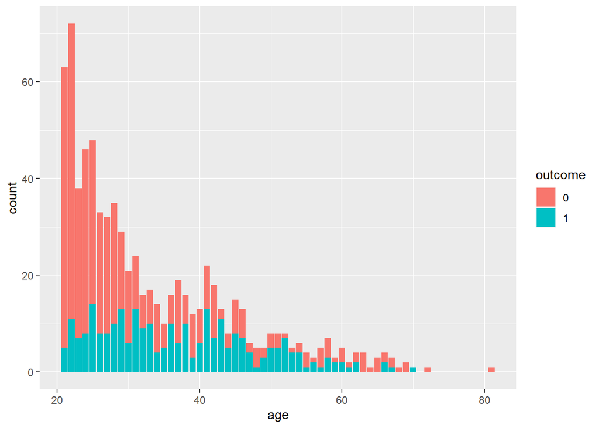

Other measurements include glucose, blood pressure, bmi, number of pregnancies (women often develop gestational diabetes while pregnant), skin thickness, family history of diabetes, and insulin levels. A widespread problem within the dataset is poorly coded missing values, which are coded as the number 0. In many cases, such as blood pressure, it is easy to interpret 0 as missing, but for values such as number of pregnancies and insulin levels, missing values are easily mixed with actual observed 0’s. Where it was deemed appropriate, the mean of the non-zero values was calculated and used to replace the 0’s. For pregnancies, no values were imputed because it is not unusual for a woman to have never been pregnant, so imputing any other value would damage the integrity of the data for no real gain.

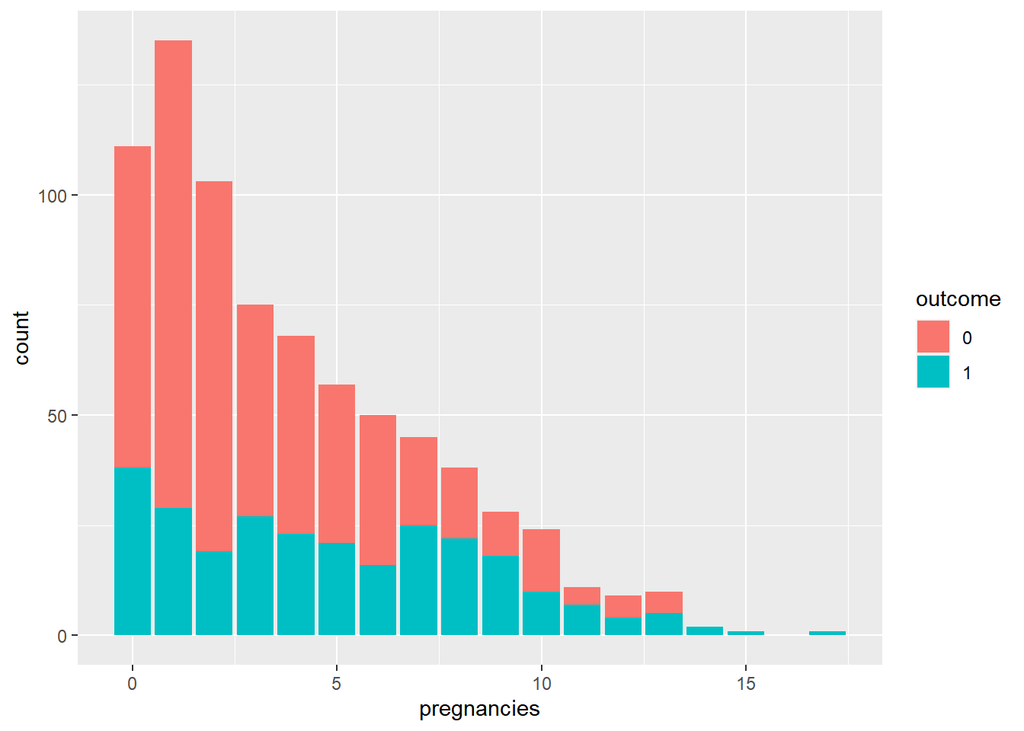

For insulin levels, since Type 2 Diabetes is literally one’s body’s inability to produce enough insulin, a different mean was imputed for diabetics and non-diabetics. For Body Mass Index, the numerical values were grouped following the CDC’s definitions for obesity, creating 4 groups.

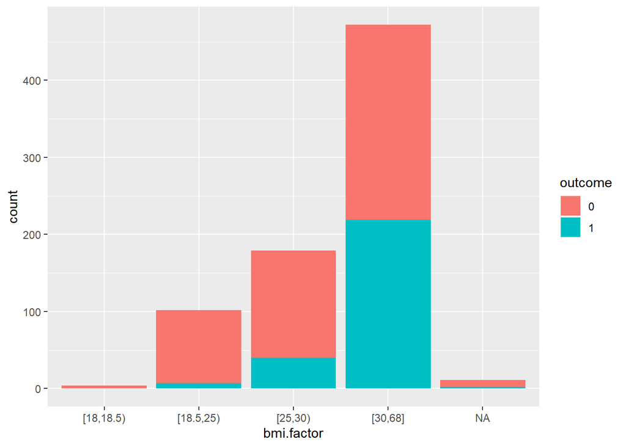

### Prediction Models

To train the prediction models, am 80/20% split was used for training/testing datasets.

After visualizing the data, stepwise logistic regression and automatic model ranking was used to further explore the data. I like doing this early in the modeling process to find patterns in the data most worth exploring. The “stats” package loaded in base R contains a function for stepwise regression, step(), that attempts to find a model that minimizes the AIC value. The “MuMln” package contains the dredge() function that takes a model and tests every subset of explanatory variables, and ranks them based on a given criteria (here that is AIC). Manually selected models were also tested.

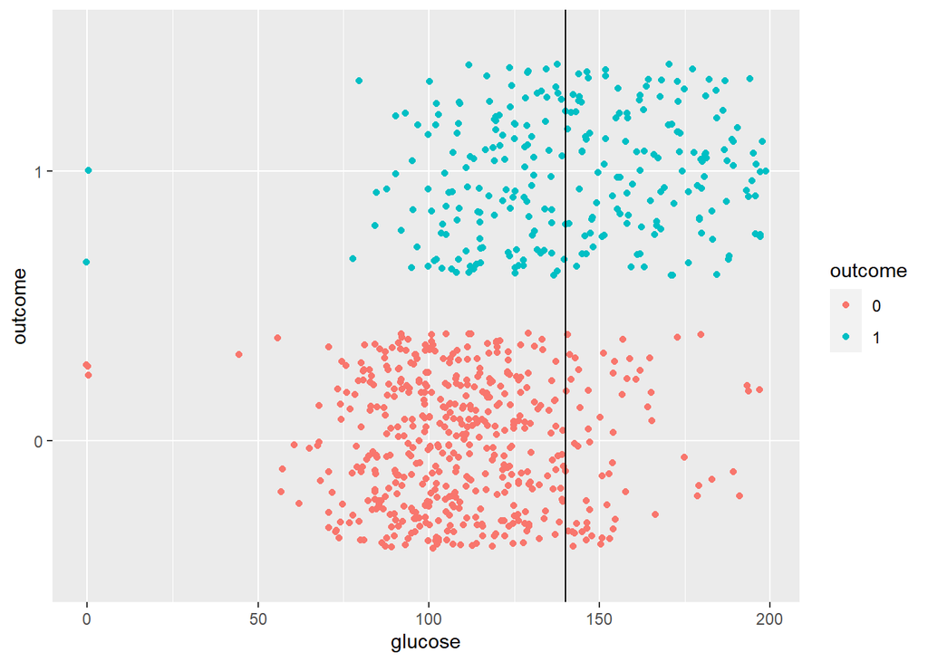

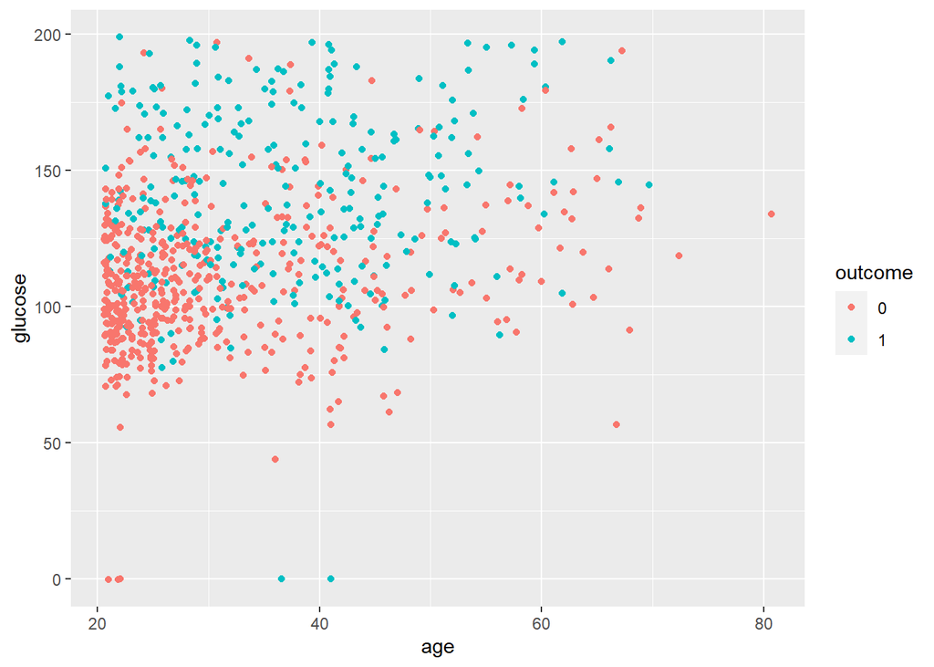

From testing low dimension models, insulin levels was the next best predictor of diabetes. However, the data on insulin featured a high number of suspected missing values (insulin = 0 was interpreted as missing), and the definition of diabetes is a lack of insulin production, so a model predicting diabetes based on insulin levels is like predicting if your house is on fire by observing if it is currently aflame.

Omitting both insulin levels and glucose test results from the models, the next best predictors was age and number of pregnancies. A model with those two variables correctly predicted 69% of the test data, and including their BMI information increased this to 74%. The following graph displays age and pregnancy data, colored by diabetic and nondiabetic, with reference lines to the average values for age and number of pregnancies.

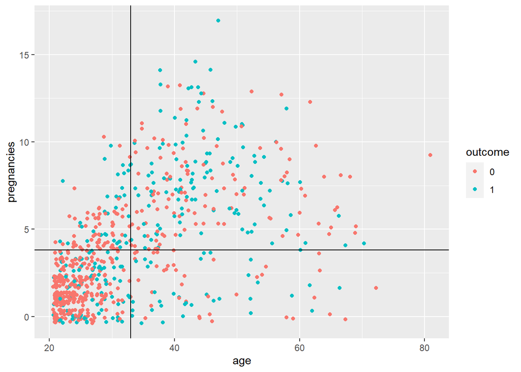

### Conclusions

With this information, two models were settled on, and a third model that combines the two:

- Diabetes Outcome = *Glucose Level + C*
- Diabetes Outcome = *Age + Number of Pregnancies + C*
- Diabetes Outcome = *Glucose Level + Age + Number of Pregnancies + C*

Model A confirms the current guidelines for testing for diabetes using an oral glucose tolerance test are helpful in identifying diabetic patients, at least for females in a community who have undergone a tremendous change in diet such as the Gila River Reservation. Model B suggests diabetes is more common as one ages and can be spurred by experiencing multiple pregnancies. These factors can be confounded by other variables – it is not unusual for any type of person to reduce physical activity as they age. The data does not say when the persons were pregnant, so the model cannot distinguish the difference of effect of pregnancy for a young person and an old person.

These models may be easily expanded to test for diabetes on a more general population, but due to the Pima Indian Community’s specific history and researcher’s exceptional interest in the community, it should be expected the models outlined above will not fit as well, and other variables should be considered. Environmental factors would be a helpful extension of the dataset: information about the prevalence of healthy foods, food deserts, family incomes, motor vehicle ownership, bicycle ownership, all could contain information useful for predicting communities most likely to develop high rates of Type 2 Diabetes.

## References

*Reference list originally compiled in 2022, links may be out of date*

Mayo Clinic. (2022, December). Glucose Tolerance Test. Retrieved from Mayo Clinic: https://www.mayoclinic.org/tests-procedures/glucose-tolerance-test/about/pac-20394296

Radin, J. (2017). “Digital Natives”: How Medical and Indigenous Histories Matter for Big Data. History of Science Society.

United States Center of Disease Control. (2022). By the Numbers: Diabetes in America. Retrieved from CDC: https://www.cdc.gov/diabetes/health-equity/diabetes-by-the-numbers.html

United States Department of Agriculture. (2022, December 18). Food Access Research Atlast. Retrieved from USDA ERS: https://www.ers.usda.gov/data-products/food-access-research-atlas/go-to-the-atlas/

Pima Indian Dataset provided by Kaggle, last updated September 19, 2019: https://www.kaggle.com/datasets/uciml/pima-indians-diabetes-database

Descriptions of data found at: https://www.researchgate.net/figure/Description-of-Pima-Indians-Diabetes-dataset_tbl1_299430176

# Code used in project

This is the R script I used to create and evaluate models. This code was never intended for public viewing, so it is has not been edited for clarity. It includes comments with URLs to websites I was referencing as I was building the models, not all that were included in the paper’s reference section.

```r
library(readr)
library(tidyverse)
library(MuMIn)
library(finalfit)
library(car)
library(caret)
set.seed(12252022)
diabetes <- read_csv(__paste path to data here__) #readr import function also works
#data can be sourced at https://www.kaggle.com/datasets/uciml/pima-indians-diabetes-database
names(diabetes) <- tolower(names(diabetes)) #lower case
diabetes$outcome <-  as.factor(diabetes$outcome) #change diabetes outcome to factor

glimpse(diabetes)
ff_glimpse(diabetes)
#https://www.researchgate.net/figure/Description-of-Pima-Indians-Diabetes-dataset_tbl1_299430176

#diabetic outcome, 1 is positive
table(diabetes$outcome) #268 diabetic, 500 not, 34.9% positive rate


#pregnancies profiling, number of pregnancies
table(diabetes$pregnancies)#frequency of pregnancies
#consider factoring three groups, 0, 1, 2+ pregnancies
summary(diabetes$pregnancies)
hist(diabetes$pregnancies, breaks = 17)
ggplot(diabetes, aes(x = pregnancies, y = outcome)) + geom_jitter() #appears to be evenly spread
table(diabetes$pregnancies, diabetes$outcome)
table(diabetes$pregnancies)

diabetes <- diabetes |> mutate(zeropregnancies = ifelse(pregnancies > 0, 0, 1)) #two groups, zero and non-zero pregnancies
diabetes$zeropregnancies <- factor(diabetes$zeropregnancies)


#age
summary(diabetes$age)
#age begins at 21, consider zeroing?
table(diabetes$age)
ggplot(diabetes, aes(x = age, fill = outcome)) + geom_bar()
table(diabetes$age, diabetes$outcome)
ggplot(diabetes, aes(x = age, y = outcome)) + geom_jitter()

diabetes <- diabetes |> mutate(agez = age - 21) #create zero'd age variable


#glucose, plasma glucose concentration
table(diabetes$glucose)
summary(diabetes$glucose)
ggplot(diabetes, aes(x = glucose, y = outcome)) + geom_jitter() #Diabetics have elevated glucose levels

diabetes$glucose[diabetes$glucose == 0] <- 121 #mean glucose level after removing zeros, to replace zeros


#bloodpressure, diastolic
summary(diabetes$bloodpressure)
table(diabetes$bloodpressure)
hist(diabetes$bloodpressure)
ggplot(diabetes, aes(x = bloodpressure, y = outcome)) + geom_jitter() #possibly group this into low, normal, high

diabetes$bloodpressure[diabetes$bloodpressure == 0] <- 72 #impute the mean

#skin thickness
summary(diabetes$skinthickness) #0 is missing value, replace with mean
table(diabetes$skinthickness)#227 missing values
plot(diabetes$skinthickness)
ggplot(diabetes, aes(x = skinthickness, y = outcome)) + geom_jitter()#mayyyyybe thicker skin for diabetics? Compare Age-Skin

diabetes$skinthickness[diabetes$skinthickness == 0] <- 29 #impute with mean

#insulin
summary(diabetes$insulin)
table(diabetes$insulin)#374 missing values, massive range
plot(diabetes$insulin)
ggplot(diabetes, aes(x = insulin, y = outcome)) + geom_jitter() #looks pretty similar in the groups

diabetes$insulin[diabetes$insulin == 0 & diabetes$outcome == 1] <- 206 #mean between diabetic and nondiabetic is different
diabetes$insulin[diabetes$insulin == 0 & diabetes$outcome == 0] <- 130 #so impute different means


#BMI
#https://www.cdc.gov/healthyweight/assessing/bmi/adult_bmi/index.html
#18.4=underweight,18.5-24.9=healthy, 25-29.9=overweight, 30+=obese
summary(diabetes$bmi) #this should absolutely be factored!
table(diabetes$bmi)#11 missing values

diabetes$bmi[diabetes$bmi == 0] <- 32 #impute mean

#create bmi.factor
diabetes <- diabetes |> mutate(bmi.factor = bmi |>
                                 cut(breaks = c(18, 18.5, 25, 30, 68), include.lowest = TRUE, right = FALSE))

table(diabetes$bmi.factor, diabetes$outcome) #pretty clear pattern of diabetes


#pedigree function
summary(diabetes$diabetespedigreefunction)
hist(diabetes$diabetespedigreefunction)
plot(diabetes$diabetespedigreefunction, diabetes$outcome)



#model selection
diabetes2 <- select(diabetes, -c(bmi, age)) #remove redundant variables in created test data
dtrain <- slice_sample(diabetes2, prop =0.8) #training data
dtest <- anti_join(diabetes2, dtrain) #testing data

diabetes2 |> select(-c(bmi.factor, outcome, zeropregnancies)) |> cor() #correlations, be sure to remove factors!

dmodel <- glm(outcome~., data = dtrain, family = "binomial")
dm <- step(dmodel, direction = "both")

dm2 <- glm(outcome ~ pregnancies + glucose + diabetespedigreefunction,
                 data = dtrain, family = "binomial")

train(outcome ~ pregnancies + glucose + insulin + diabetespedigreefunction + bmi.factor,
      data = dtest, method = "glm", family = "binomial")
#stepwise regression yields 80% accuracy

#glucose and insulin are heavily correlated
train(outcome ~ pregnancies + glucose + diabetespedigreefunction,
      data = dtest, method = "glm", family = "binomial")
#removing insulin + bmi.factor yields 76% accuracy
#glucose only yields 73%
tibble(dtrain$outcome, ifelse(dtrain$glucose > 140, 1,0)) |> table() # glucose @ 140 predicts 73%
#https://www.mayoclinic.org/tests-procedures/glucose-tolerance-test/about/pac-20394296
#140 is baseline for 'prediabetes'
#https://www.statisticshowto.com/log-odds/
#glm logistic produces log odds

ggplot(diabetes, aes(x = glucose, y = bloodpressure)) + geom_jitter(aes(color = outcome))
ggplot(diabetes, aes(x = bmi.factor, y = bloodpressure)) + geom_jitter(aes(color = outcome))
ggplot(diabetes, aes(x = glucose, y = outcome)) + geom_jitter(aes(color = outcome)) + geom_vline(xintercept = 140)
#reference lines are averages
ggplot(data = diabetes, aes(x = age, y = pregnancies, color = outcome)) + geom_jitter() + geom_vline(xintercept = mean(diabetes$age)) + geom_hline(yintercept = mean(diabetes$pregnancies))

#dredge model exploration
fullmodel <- glm(outcome~., data = dtrain, family = "binomial")
options(na.action = "na.fail")
dredgers <- dredge(fullmodel, evaluate = TRUE)
dredge(fullmodel, evaluate = TRUE, m.lim = c(1,2))

#fitting non-glucose non-insulin variables
glm(outcome~pregnancies + bloodpressure + skinthickness + bmi.factor + diabetespedigreefunction + agez, data = dtest, family = "binomial") |> dredge(evaluate = TRUE, m.lim = c(1,3))
glm(outcome~pregnancies + agez, data = dtest, family = "binomial")
train(outcome ~ pregnancies + agez, data = dtest, method = "glm", family = "binomial")

#final model
finalmodel <- glm(outcome~glucose + agez + pregnancies, data = diabetes, family = "binomial")
train(outcome~glucose + agez + pregnancies, data = diabetes, method = "glm", family = "binomial")
vif(dmodel) #multicollinearity for model with all columns
vif(finalmodel) #testing for multicollinearity for final model
```